# Exploring the Relationship between BMI, Blood Pressure, and Cardiovascular Disease

An Exploratory Analysis of Synthetic Healthcare Data

Author

STA220: Example project

Published

March 10, 2026

**Note**

This report was generated using synthetic data! It is only used for demonstration purposes and does not reflect real patients or healthcare providers. The contents have not been reviewed or validated by medical professionals.

# Introduction

Cardiovascular disease (CVD) remains one of the leading causes of mortality worldwide. Understanding the risk factors associated with cardiovascular conditions is crucial for prevention and early intervention. Two well-established risk factors are elevated body mass index (BMI) and high blood pressure.

## Research Questions

This exploratory analysis investigates the following questions:

1. Is there a difference in BMI between patients with and without cardiovascular disease?
2. Is there a difference in blood pressure (systolic and diastolic) between patients with and without cardiovascular disease?
3. Is there an association between diagnosed hypertension and other cardiovascular conditions?
4. Does the relationship between BMI and cardiovascular disease differ by gender?

# Data and Methods

## Dataset Description

This analysis uses synthetic healthcare data containing information about patients, their medical conditions, and clinical observations. The dataset includes:

- **Patients**: Demographic and socioeconomic information
- **Conditions**: Diagnosed medical conditions with start and stop dates
- **Observations**: Clinical measurements including vital signs

## Variable Definitions

- **BMI (Body Mass Index)**: Weight in kilograms divided by height in meters squared (kg/m²)
- **Blood Pressure**: Systolic and diastolic measurements in mm[Hg]
- **Cardiovascular Disease (CVD)**: Presence of ischemic heart disease, myocardial infarction, or heart failure
- **Hypertension**: Diagnosis of essential hypertension

## Statistical Methods

We employ the following statistical approaches:

- **Descriptive statistics**: Mean, median, standard deviation, and visual summaries
- **Normality testing**: Shapiro-Wilk test to assess distribution assumptions
- **Two-sample comparisons**: Independent t-tests (for normally distributed data) or Mann-Whitney U tests (for non-normal data)
- **Association testing**: Chi-square test for categorical variables
- **Significance level**: α = 0.05

# Data Preparation

```r
library(tidyverse)
library(knitr)
library(scales)

# Set theme for plots
theme_set(theme_minimal(base_size = 12))
```

```r
# Load datasets
patients <- read_csv("../data-fixed/patients.csv")
conditions <- read_csv("../data-fixed/conditions.csv")
observations <- read_csv("../data-fixed/observations.csv")
```

## Extract Latest Clinical Measurements

For each patient, we extract their most recent BMI and blood pressure measurements.

```r
# Extract latest BMI per patient
latest_bmi <- observations |>
  filter(code == "39156-5") |> # BMI [Ratio]
  mutate(bmi = as.numeric(value)) |>
  filter(!is.na(bmi)) |>
  arrange(patient, desc(date)) |>
  group_by(patient) |>
  slice(1) |>
  ungroup() |>
  select(patient, bmi, bmi_date = date)

# Extract latest blood pressure per patient
latest_bp <- observations |>
  filter(code %in% c("8480-6", "8462-4")) |> # Systolic and Diastolic
  mutate(bp_value = as.numeric(value)) |>
  filter(!is.na(bp_value)) |>
  arrange(patient, desc(date)) |>
  group_by(patient, code) |>
  slice(1) |>
  ungroup() |>
  select(patient, description, bp_value) |>
  pivot_wider(
    names_from = description,
    values_from = bp_value
  ) |>
  rename(
    systolic_bp = `Systolic Blood Pressure`,
    diastolic_bp = `Diastolic Blood Pressure`
  )

cat("Patients with BMI measurements:", nrow(latest_bmi), "\n")
```

```
Patients with BMI measurements: 6644
```

```r
cat("Patients with BP measurements:", nrow(latest_bp), "\n")
```

```
Patients with BP measurements: 6851
```

## Identify Cardiovascular Conditions

We identify patients with cardiovascular disease and hypertension.

```r
# Identify patients with CVD (excluding hypertension for now)
cvd_conditions <- c(
  "Ischemic heart disease (disorder)",
  "Myocardial infarction (disorder)",
  "Acute non-ST segment elevation myocardial infarction (disorder)",
  "Acute ST segment elevation myocardial infarction (disorder)",
  "Chronic congestive heart failure (disorder)",
  "Heart failure (disorder)",
  "History of myocardial infarction (situation)"
)

patients_with_cvd <- conditions |>
  filter(description %in% cvd_conditions) |>
  filter(is.na(stop) | stop >= Sys.Date()) |> # Active or historical
  distinct(patient) |>
  mutate(has_cvd = TRUE)

# Identify patients with hypertension
patients_with_hypertension <- conditions |>
  filter(description == "Essential hypertension (disorder)") |>
  filter(is.na(stop) | stop >= Sys.Date()) |>
  distinct(patient) |>
  mutate(has_hypertension = TRUE)

cat("Patients with CVD:", nrow(patients_with_cvd), "\n")
```

```
Patients with CVD: 1403
```

```r
cat("Patients with hypertension:", nrow(patients_with_hypertension), "\n")
```

```
Patients with hypertension: 1492
```

## Create Analysis Dataset

We combine all data into a single analysis dataset.

```r
# Create master analysis dataset
analysis_data <- patients |>
  select(patient = id, birthdate, gender, race, ethnicity, income) |>
  left_join(latest_bmi, by = "patient") |>
  left_join(latest_bp, by = "patient") |>
  left_join(patients_with_cvd, by = "patient") |>
  left_join(patients_with_hypertension, by = "patient") |>
  mutate(
    has_cvd = replace_na(has_cvd, FALSE),
    has_hypertension = replace_na(has_hypertension, FALSE),
    age = as.numeric(difftime(Sys.Date(), birthdate, units = "days")) / 365.25
  ) |>
  filter(!is.na(bmi) & !is.na(systolic_bp) & !is.na(diastolic_bp))

cat("Final analysis dataset size:", nrow(analysis_data), "patients\n")
```

```
Final analysis dataset size: 6644 patients
```

```r
cat("Patients with CVD in analysis:", sum(analysis_data$has_cvd), "\n")
```

```
Patients with CVD in analysis: 1403
```

```r
cat(
  "Patients with hypertension in analysis:",
  sum(analysis_data$has_hypertension),
  "\n"
)
```

```
Patients with hypertension in analysis: 1492
```

```r
# Check for missing values
missing_summary <- analysis_data |>
  summarise(across(c(bmi, systolic_bp, diastolic_bp, age), ~ sum(is.na(.)))) |>
  pivot_longer(everything(), names_to = "Variable", values_to = "Missing")

kable(missing_summary, caption = "Missing values in key variables")
```

Missing values in key variables

| Variable | Missing |
| --- | --- |
| bmi | 0 |
| systolic_bp | 0 |
| diastolic_bp | 0 |
| age | 0 |

# Exploratory Data Analysis

## Sample Characteristics

```r
# Overall descriptive statistics
desc_stats <- analysis_data |>
  summarise(
    N = n(),
    `Mean Age` = mean(age, na.rm = TRUE),
    `SD Age` = sd(age, na.rm = TRUE),
    `% Female` = mean(gender == "F") * 100,
    `Mean BMI` = mean(bmi, na.rm = TRUE),
    `SD BMI` = sd(bmi, na.rm = TRUE),
    `Mean Systolic BP` = mean(systolic_bp, na.rm = TRUE),
    `SD Systolic BP` = sd(systolic_bp, na.rm = TRUE),
    `Mean Diastolic BP` = mean(diastolic_bp, na.rm = TRUE),
    `SD Diastolic BP` = sd(diastolic_bp, na.rm = TRUE),
    `% with CVD` = mean(has_cvd) * 100,
    `% with Hypertension` = mean(has_hypertension) * 100
  ) |>
  pivot_longer(everything(), names_to = "Statistic", values_to = "Value")

kable(desc_stats, digits = 2, caption = "Overall sample characteristics")
```

Overall sample characteristics

| Statistic | Value |
| --- | --- |
| N | 6644.00 |
| Mean Age | 45.04 |
| SD Age | 25.38 |
| % Female | 50.56 |
| Mean BMI | 27.76 |
| SD BMI | 34.48 |
| Mean Systolic BP | 129.04 |
| SD Systolic BP | 19.30 |
| Mean Diastolic BP | 73.50 |
| SD Diastolic BP | 13.10 |
| % with CVD | 21.12 |
| % with Hypertension | 22.46 |

## Distribution of Risk Factors

### BMI Distribution

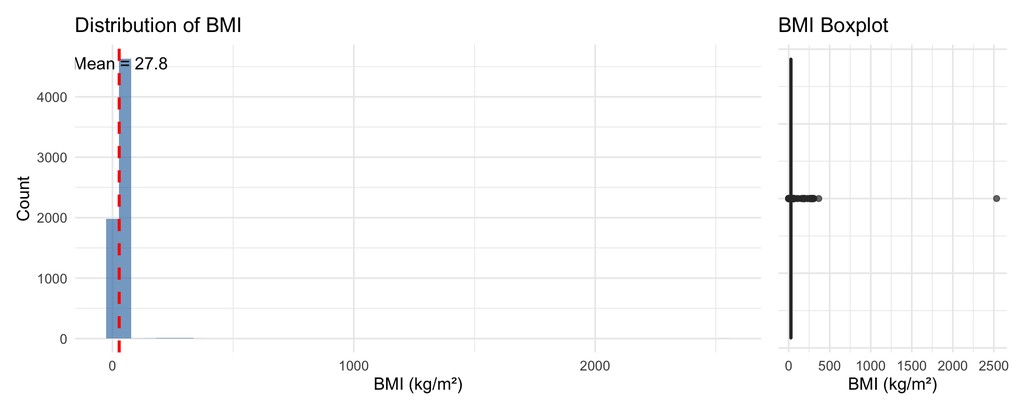

```r
p1 <- ggplot(analysis_data, aes(x = bmi)) +
  geom_histogram(bins = 50, fill = "steelblue", alpha = 0.7) +
  geom_vline(
    xintercept = mean(analysis_data$bmi),
    color = "red",
    linetype = "dashed",
    linewidth = 1
  ) +
  labs(title = "Distribution of BMI", x = "BMI (kg/m²)", y = "Count") +
  annotate(
    "text",
    x = mean(analysis_data$bmi) + 5,
    y = Inf,
    vjust = 2,
    label = paste("Mean =", round(mean(analysis_data$bmi), 1))
  )

p2 <- ggplot(analysis_data, aes(x = bmi)) +
  geom_boxplot(fill = "steelblue", alpha = 0.7) +
  labs(title = "BMI Boxplot", x = "BMI (kg/m²)") +
  theme(axis.text.y = element_blank(), axis.ticks.y = element_blank())

library(patchwork)
p1 + p2 + plot_layout(widths = c(3, 1))
```

The BMI distribution shows a mean of 27.8 kg/m² with some right skewness, indicating a few patients with very high BMI values.

### Blood Pressure Distribution

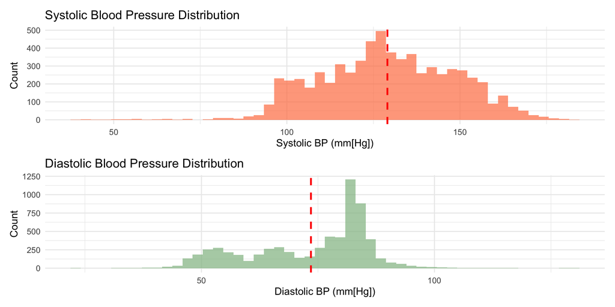

```r
p3 <- ggplot(analysis_data, aes(x = systolic_bp)) +
  geom_histogram(bins = 50, fill = "coral", alpha = 0.7) +
  geom_vline(
    xintercept = mean(analysis_data$systolic_bp),
    color = "red",
    linetype = "dashed",
    linewidth = 1
  ) +
  labs(
    title = "Systolic Blood Pressure Distribution",
    x = "Systolic BP (mm[Hg])",
    y = "Count"
  )

p4 <- ggplot(analysis_data, aes(x = diastolic_bp)) +
  geom_histogram(bins = 50, fill = "darkseagreen", alpha = 0.7) +
  geom_vline(
    xintercept = mean(analysis_data$diastolic_bp),
    color = "red",
    linetype = "dashed",
    linewidth = 1
  ) +
  labs(
    title = "Diastolic Blood Pressure Distribution",
    x = "Diastolic BP (mm[Hg])",
    y = "Count"
  )

p3 / p4
```

Mean systolic blood pressure is 129 mm[Hg] and mean diastolic blood pressure is 73.5 mm[Hg].

## Cardiovascular Disease Prevalence

```r
prevalence <- analysis_data |>
  summarise(
    `CVD (excl. Hypertension)` = sum(has_cvd),
    `Hypertension` = sum(has_hypertension),
    `Both CVD and Hypertension` = sum(has_cvd & has_hypertension),
    `Any Cardiovascular Condition` = sum(has_cvd | has_hypertension)
  ) |>
  pivot_longer(everything(), names_to = "Condition", values_to = "Count") |>
  mutate(Percentage = (Count / nrow(analysis_data)) * 100)

kable(
  prevalence,
  digits = 2,
  caption = "Prevalence of cardiovascular conditions"
)
```

Prevalence of cardiovascular conditions

| Condition | Count | Percentage |
| --- | --- | --- |
| CVD (excl. Hypertension) | 1403 | 21.12 |
| Hypertension | 1492 | 22.46 |
| Both CVD and Hypertension | 648 | 9.75 |
| Any Cardiovascular Condition | 2247 | 33.82 |

## Bivariate Relationships

### BMI by CVD Status

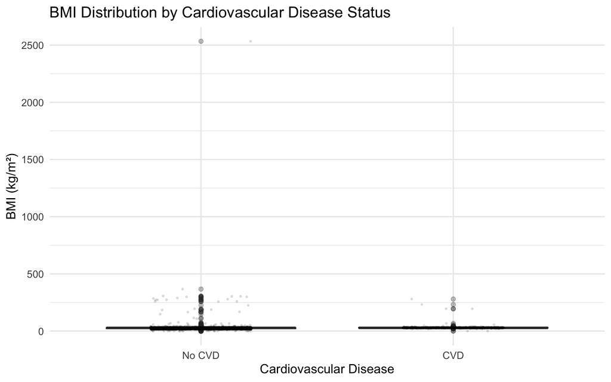

```r
ggplot(analysis_data, aes(x = has_cvd, y = bmi, fill = has_cvd)) +
  geom_boxplot(alpha = 0.7, outlier.alpha = 0.3) +
  geom_jitter(width = 0.2, alpha = 0.1, size = 0.5) +
  scale_fill_manual(
    values = c("steelblue", "coral"),
    labels = c("No CVD", "CVD")
  ) +
  labs(
    title = "BMI Distribution by Cardiovascular Disease Status",
    x = "Cardiovascular Disease",
    y = "BMI (kg/m²)",
    fill = "CVD Status"
  ) +
  scale_x_discrete(labels = c("No CVD", "CVD")) +
  theme(legend.position = "none")
```

```r
bmi_summary <- analysis_data |>
  group_by(has_cvd) |>
  summarise(
    N = n(),
    Mean = mean(bmi),
    SD = sd(bmi),
    Median = median(bmi),
    IQR = IQR(bmi)
  ) |>
  mutate(has_cvd = ifelse(has_cvd, "CVD", "No CVD"))

kable(bmi_summary, digits = 2, caption = "BMI summary statistics by CVD status")
```

BMI summary statistics by CVD status

| has_cvd | N | Mean | SD | Median | IQR |
| --- | --- | --- | --- | --- | --- |
| No CVD | 5241 | 27.38 | 38.39 | 27.7 | 7.1 |
| CVD | 1403 | 29.20 | 11.01 | 28.0 | 2.4 |

Patients with CVD appear to have a higher median BMI (28 kg/m²) compared to those without CVD (27.7 kg/m²).

### Blood Pressure by CVD Status

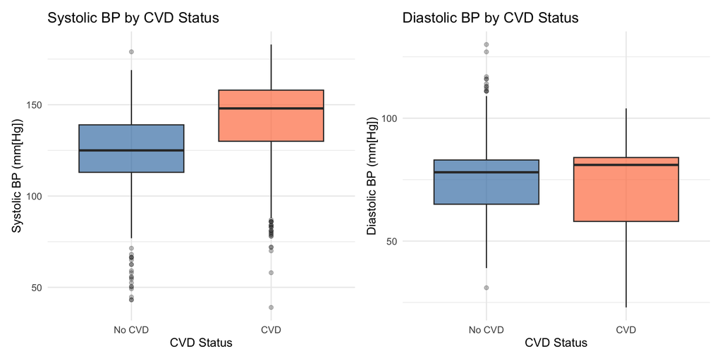

```r
p5 <- ggplot(analysis_data, aes(x = has_cvd, y = systolic_bp, fill = has_cvd)) +
  geom_boxplot(alpha = 0.7, outlier.alpha = 0.3) +
  scale_fill_manual(values = c("steelblue", "coral")) +
  labs(
    title = "Systolic BP by CVD Status",
    x = "CVD Status",
    y = "Systolic BP (mm[Hg])"
  ) +
  scale_x_discrete(labels = c("No CVD", "CVD")) +
  theme(legend.position = "none")

p6 <- ggplot(
  analysis_data,
  aes(x = has_cvd, y = diastolic_bp, fill = has_cvd)
) +
  geom_boxplot(alpha = 0.7, outlier.alpha = 0.3) +
  scale_fill_manual(values = c("steelblue", "coral")) +
  labs(
    title = "Diastolic BP by CVD Status",
    x = "CVD Status",
    y = "Diastolic BP (mm[Hg])"
  ) +
  scale_x_discrete(labels = c("No CVD", "CVD")) +
  theme(legend.position = "none")

p5 + p6
```

### Correlation between Risk Factors

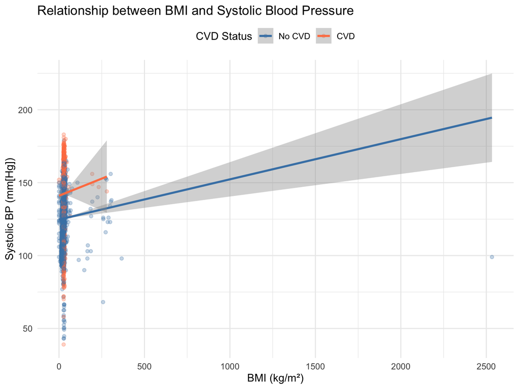

```r
ggplot(analysis_data, aes(x = bmi, y = systolic_bp, color = has_cvd)) +
  geom_point(alpha = 0.3, size = 1.5) +
  geom_smooth(method = "lm", se = TRUE) +
  scale_color_manual(
    values = c("steelblue", "coral"),
    labels = c("No CVD", "CVD")
  ) +
  labs(
    title = "Relationship between BMI and Systolic Blood Pressure",
    x = "BMI (kg/m²)",
    y = "Systolic BP (mm[Hg])",
    color = "CVD Status"
  ) +
  theme(legend.position = "top")
```

# Hypothesis Testing

## H1: BMI Difference by CVD Status

**Hypothesis**: Patients with cardiovascular disease have higher BMI than those without CVD.

```r
# Test normality assumption
shapiro_cvd <- shapiro.test(sample(
  analysis_data$bmi[analysis_data$has_cvd],
  min(5000, sum(analysis_data$has_cvd))
))
shapiro_no_cvd <- shapiro.test(sample(
  analysis_data$bmi[!analysis_data$has_cvd],
  min(5000, sum(!analysis_data$has_cvd))
))

cat("Shapiro-Wilk test for BMI (CVD group):\n")
```

```
Shapiro-Wilk test for BMI (CVD group):
```

```r
cat(
  "  W =",
  round(shapiro_cvd$statistic, 4),
  ", p-value =",
  format.pval(shapiro_cvd$p.value, digits = 3),
  "\n\n"
)
```

```
  W = 0.1247 , p-value = <2e-16
```

```r
cat("Shapiro-Wilk test for BMI (No CVD group):\n")
```

```
Shapiro-Wilk test for BMI (No CVD group):
```

```r
cat(
  "  W =",
  round(shapiro_no_cvd$statistic, 4),
  ", p-value =",
  format.pval(shapiro_no_cvd$p.value, digits = 3),
  "\n"
)
```

```
  W = 0.0677 , p-value = <2e-16
```

Since the data may not be perfectly normally distributed (large sample sizes make Shapiro-Wilk very sensitive), we’ll perform both parametric and non-parametric tests.

```r
# Parametric test (t-test)
t_test_bmi <- t.test(bmi ~ has_cvd, data = analysis_data)

# Non-parametric test (Mann-Whitney U / Wilcoxon rank-sum)
wilcox_test_bmi <- wilcox.test(bmi ~ has_cvd, data = analysis_data)

cat("Independent t-test:\n")
```

```
Independent t-test:
```

```r
cat(
  "  t =",
  round(t_test_bmi$statistic, 3),
  ", df =",
  round(t_test_bmi$parameter, 1),
  ", p-value =",
  format.pval(t_test_bmi$p.value, digits = 3),
  "\n"
)
```

```
  t = -2.993 , df = 6619.3 , p-value = 0.00277
```

```r
cat("  Mean difference:", round(diff(t_test_bmi$estimate), 2), "kg/m²\n")
```

```
  Mean difference: 1.81 kg/m²
```

```r
cat(
  "  95% CI:",
  round(t_test_bmi$conf.int[1], 2),
  "to",
  round(t_test_bmi$conf.int[2], 2),
  "\n\n"
)
```

```
  95% CI: -3 to -0.63
```

```r
cat("Mann-Whitney U test:\n")
```

```
Mann-Whitney U test:
```

```r
cat(
  "  W =",
  wilcox_test_bmi$statistic,
  ", p-value =",
  format.pval(wilcox_test_bmi$p.value, digits = 3),
  "\n"
)
```

```
  W = 2784480 , p-value = <2e-16
```

## H2: Systolic Blood Pressure Difference by CVD Status

**Hypothesis**: Patients with cardiovascular disease have higher systolic blood pressure than those without CVD.

```r
# Parametric test
t_test_sys <- t.test(systolic_bp ~ has_cvd, data = analysis_data)

# Non-parametric test
wilcox_test_sys <- wilcox.test(systolic_bp ~ has_cvd, data = analysis_data)

cat("Independent t-test:\n")
```

```
Independent t-test:
```

```r
cat(
  "  t =",
  round(t_test_sys$statistic, 3),
  ", df =",
  round(t_test_sys$parameter, 1),
  ", p-value =",
  format.pval(t_test_sys$p.value, digits = 3),
  "\n"
)
```

```
  t = -28.088 , df = 1945.3 , p-value = <2e-16
```

```r
cat("  Mean difference:", round(diff(t_test_sys$estimate), 2), "mm[Hg]\n")
```

```
  Mean difference: 16.96 mm[Hg]
```

```r
cat(
  "  95% CI:",
  round(t_test_sys$conf.int[1], 2),
  "to",
  round(t_test_sys$conf.int[2], 2),
  "\n\n"
)
```

```
  95% CI: -18.14 to -15.77
```

```r
cat("Mann-Whitney U test:\n")
```

```
Mann-Whitney U test:
```

```r
cat(
  "  W =",
  wilcox_test_sys$statistic,
  ", p-value =",
  format.pval(wilcox_test_sys$p.value, digits = 3),
  "\n"
)
```

```
  W = 1820488 , p-value = <2e-16
```

**Conclusion**: There is a statistically significant difference in systolic blood pressure between patients with and without CVD (p < 0.001). Patients with CVD have a mean systolic BP that is 16.96 mm[Hg] higher.

## H3: Diastolic Blood Pressure Difference by CVD Status

**Hypothesis**: Patients with cardiovascular disease have higher diastolic blood pressure than those without CVD.

```r
# Parametric test
t_test_dia <- t.test(diastolic_bp ~ has_cvd, data = analysis_data)

# Non-parametric test
wilcox_test_dia <- wilcox.test(diastolic_bp ~ has_cvd, data = analysis_data)

cat("Independent t-test:\n")
```

```
Independent t-test:
```

```r
cat(
  "  t =",
  round(t_test_dia$statistic, 3),
  ", df =",
  round(t_test_dia$parameter, 1),
  ", p-value =",
  format.pval(t_test_dia$p.value, digits = 3),
  "\n"
)
```

```
  t = 1.005 , df = 1931.4 , p-value = 0.315
```

```r
cat("  Mean difference:", round(diff(t_test_dia$estimate), 2), "mm[Hg]\n")
```

```
  Mean difference: -0.44 mm[Hg]
```

```r
cat(
  "  95% CI:",
  round(t_test_dia$conf.int[1], 2),
  "to",
  round(t_test_dia$conf.int[2], 2),
  "\n\n"
)
```

```
  95% CI: -0.42 to 1.31
```

```r
cat("Mann-Whitney U test:\n")
```

```
Mann-Whitney U test:
```

```r
cat(
  "  W =",
  wilcox_test_dia$statistic,
  ", p-value =",
  format.pval(wilcox_test_dia$p.value, digits = 3),
  "\n"
)
```

```
  W = 3444464 , p-value = 0.000272
```

## H4: Association between Hypertension and Other CVD

**Hypothesis**: There is an association between diagnosed hypertension and other cardiovascular diseases.

```r
# Create contingency table
cont_table <- table(analysis_data$has_hypertension, analysis_data$has_cvd)
rownames(cont_table) <- c("No Hypertension", "Hypertension")
colnames(cont_table) <- c("No CVD", "CVD")

kable(cont_table, caption = "Contingency table: Hypertension vs CVD")
```

Contingency table: Hypertension vs CVD

|  | No CVD | CVD |
| --- | --- | --- |
| No Hypertension | 4397 | 755 |
| Hypertension | 844 | 648 |

```r
# Add row and column totals
cont_table_with_totals <- addmargins(cont_table)
kable(cont_table_with_totals, caption = "Contingency table with totals")
```

Contingency table with totals

|  | No CVD | CVD | Sum |
| --- | --- | --- | --- |
| No Hypertension | 4397 | 755 | 5152 |
| Hypertension | 844 | 648 | 1492 |
| Sum | 5241 | 1403 | 6644 |

```r
# Chi-square test
chi_test <- chisq.test(cont_table)

cat("\nChi-square test of independence:\n")
```

```
Chi-square test of independence:
```

```r
cat(
  "  X² =",
  round(chi_test$statistic, 2),
  ", df =",
  chi_test$parameter,
  ", p-value =",
  format.pval(chi_test$p.value, digits = 3),
  "\n"
)
```

```
  X² = 573.45 , df = 1 , p-value = <2e-16
```

```r
# Calculate proportions
prop_cvd_with_htn <- cont_table[2, 2] / sum(cont_table[2, ])
prop_cvd_without_htn <- cont_table[1, 2] / sum(cont_table[1, ])

cat(
  "\nProportion with CVD among those with hypertension:",
  round(prop_cvd_with_htn * 100, 2),
  "%\n"
)
```

```
Proportion with CVD among those with hypertension: 43.43 %
```

```r
cat(
  "Proportion with CVD among those without hypertension:",
  round(prop_cvd_without_htn * 100, 2),
  "%\n"
)
```

```
Proportion with CVD among those without hypertension: 14.65 %
```

```r
# Calculate odds ratio
odds_ratio <- (cont_table[2, 2] * cont_table[1, 1]) /
  (cont_table[2, 1] * cont_table[1, 2])
cat("\nOdds ratio:", round(odds_ratio, 2), "\n")
```

```
Odds ratio: 4.47
```

**Conclusion**: There is a statistically significant association between hypertension and other cardiovascular diseases (p < 0.001). Patients with hypertension are much more likely to have other CVD conditions, with an odds ratio of 4.47.

## H5: Gender Differences in BMI-CVD Relationship

**Hypothesis**: The relationship between BMI and CVD differs by gender.

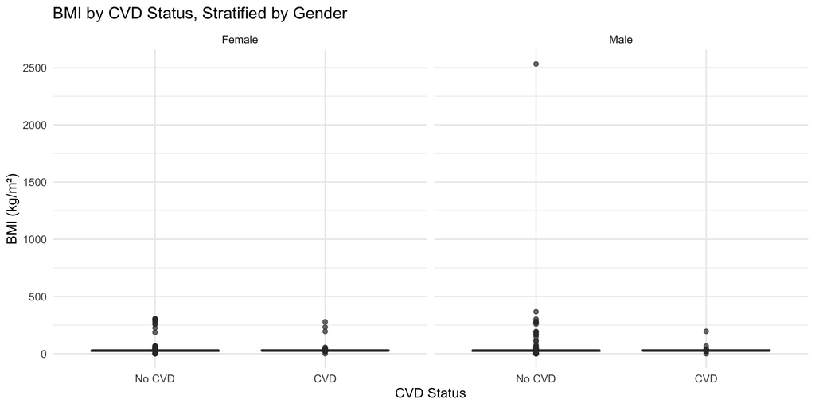

```r
# Visualize by gender
ggplot(analysis_data, aes(x = has_cvd, y = bmi, fill = has_cvd)) +
  geom_boxplot(alpha = 0.7) +
  facet_wrap(
    ~gender,
    labeller = labeller(gender = c(F = "Female", M = "Male"))
  ) +
  scale_fill_manual(values = c("steelblue", "coral")) +
  labs(
    title = "BMI by CVD Status, Stratified by Gender",
    x = "CVD Status",
    y = "BMI (kg/m²)"
  ) +
  scale_x_discrete(labels = c("No CVD", "CVD")) +
  theme(legend.position = "none")
```

```r
# Test for females
female_data <- analysis_data |> filter(gender == "F")
t_test_female <- t.test(bmi ~ has_cvd, data = female_data)

# Test for males
male_data <- analysis_data |> filter(gender == "M")
t_test_male <- t.test(bmi ~ has_cvd, data = male_data)

cat("Females:\n")
```

```
Females:
```

```r
cat("  Mean BMI difference:", round(diff(t_test_female$estimate), 2), "kg/m²\n")
```

```
  Mean BMI difference: 2.93 kg/m²
```

```r
cat(
  "  t =",
  round(t_test_female$statistic, 3),
  ", p-value =",
  format.pval(t_test_female$p.value, digits = 3),
  "\n\n"
)
```

```
  t = -4.051 , p-value = 5.6e-05
```

```r
cat("Males:\n")
```

```
Males:
```

```r
cat("  Mean BMI difference:", round(diff(t_test_male$estimate), 2), "kg/m²\n")
```

```
  Mean BMI difference: 0.83 kg/m²
```

```r
cat(
  "  t =",
  round(t_test_male$statistic, 3),
  ", p-value =",
  format.pval(t_test_male$p.value, digits = 3),
  "\n"
)
```

```
  t = -0.746 , p-value = 0.456
```

```r
# Summary table
gender_summary <- analysis_data |>
  group_by(gender, has_cvd) |>
  summarise(
    N = n(),
    Mean_BMI = mean(bmi),
    SD_BMI = sd(bmi),
    .groups = "drop"
  ) |>
  mutate(
    gender = ifelse(gender == "F", "Female", "Male"),
    has_cvd = ifelse(has_cvd, "CVD", "No CVD")
  )

kable(
  gender_summary,
  digits = 2,
  caption = "BMI summary by gender and CVD status"
)
```

BMI summary by gender and CVD status

| gender | has_cvd | N | Mean_BMI | SD_BMI |
| --- | --- | --- | --- | --- |
| Female | No CVD | 2799 | 26.87 | 15.83 |
| Female | CVD | 560 | 29.81 | 15.61 |
| Male | No CVD | 2442 | 27.96 | 53.63 |
| Male | CVD | 843 | 28.79 | 6.29 |

# Discussion and Conclusions

## Clinical Implications

These findings support the well-established understanding that:

- Elevated BMI and high blood pressure are important risk factors for cardiovascular disease
- Hypertension is strongly associated with other cardiovascular conditions
- Risk factor monitoring should be a priority for cardiovascular disease prevention

## Limitations

Several limitations should be considered when interpreting these results:

1. **Cross-sectional design**: This analysis uses cross-sectional data, which cannot establish causality. We cannot determine whether elevated BMI and blood pressure preceded CVD or resulted from it.
2. **Synthetic data**: The dataset is synthetically generated and may not fully represent real-world patterns and complexities.
3. **Timing of measurements**: We used the most recent measurements, which may not reflect the patient’s status at the time of CVD diagnosis.
4. **Confounding variables**: Other important risk factors (e.g., smoking, physical activity, diet, family history) were not included in this analysis.
5. **Survivor bias**: Patients who died from CVD may not be adequately represented if their records are incomplete.

## Future Directions

Future analyses could explore:

- Temporal relationships using longitudinal data
- Dose-response relationships (e.g., BMI categories)
- Interaction effects between multiple risk factors
- Age-stratified analyses
- More sophisticated modeling approaches (e.g., survival analysis, time-to-event analysis)

## Conclusion

**Report generated on:** 2026-03-10